# Benjamin_Individual_Model1st

Benjamin Huynh

2025-11-17

```r
data <- read_csv("combined_teams.csv")
head(data)
```

```
## # A tibble: 6 × 89
##   Tm       `#Bat` BatAge `R/G`    PA    AB R_Bat H_Bats `2B_Bat` `3B_Bat` HR_Bat
##   <chr>     <dbl>  <dbl> <dbl> <dbl> <dbl> <dbl>  <dbl>    <dbl>    <dbl>  <dbl>
## 1 Arizona…     51   28.6  5.47  6284  5522   886   1452      271       37    211
## 2 Atlanta…     55   29.3  4.35  6075  5481   704   1333      273       15    213
## 3 Baltimo…     60   26.9  4.85  6176  5567   786   1391      262       33    235
## 4 Boston …     57   27.3  4.64  6192  5577   751   1404      311       30    194
## 5 Chicago…     56   27.8  4.54  6116  5441   736   1318      253       29    170
## 6 Chicago…     63   27.8  3.13  5869  5383   507   1187      226        9    133
## # ℹ 78 more variables: RBI <dbl>, SB <dbl>, CS <dbl>, BB_Bat <dbl>,
## #   SO_Bat <dbl>, BA <dbl>, OBP <dbl>, SLG <dbl>, OPS <dbl>, `OPS+` <dbl>,
## #   TB <dbl>, GDP <dbl>, HBP_Bat <dbl>, SH <dbl>, SF <dbl>, IBB_Bat <dbl>,
## #   LOB_Bat <dbl>, `#Fld` <dbl>, `RA/G_P` <dbl>, DefEff <dbl>, CG_F <dbl>,
## #   Inn <dbl>, Ch <dbl>, PO <dbl>, A <dbl>, E <dbl>, DP <dbl>, `Fld%` <dbl>,
## #   Rtot <dbl>, `Rtot/yr` <dbl>, Rdrs <dbl>, `Rdrs/yr` <dbl>, Rgood <dbl>,
## #   `#P` <dbl>, PAge <dbl>, W <dbl>, ERA <dbl>, tSho <dbl>, cSho <dbl>, …
```

## 1. Step 1 - Model Specification

H9 - Hits per 9 innings - pitching Non-P - non-pitcher postions(fielding) - position HitAllow - Hits Allowed - pitching ERA - earned run average(how effective pitchers prevent runs) - pitching RA/G_P - runs allowed per game - pitching DefEff - defensive efficiency - fielding OPS+ - on base percentage + slugging percentage - batting R/G - runs scored per game - batting WHIP - walks + hits per inning pitched - pitching

R_P - Redundant Same as RA/G_D but divided by number of games, has a lower coefficient. ER - Redundant Same as ERA but total, not average earned runs, has a lower coefficient. OBP - Redundant on base percentage but not slugging percentage, has a lower coefficient.

Although I eliminated these for the first model they still potentially might provide value for the future but at the moment they are eliminated.

```r
set.seed(123)

n <- nrow(data)
train_index <- sample(1:n, size = 0.7 * n)
train_data <- data[train_index, ]
test_data  <- data[-train_index, ]

y_var <- "W"

model1 <- lm(
  as.formula("W ~ H9 + `Non-P` + HitAllow + ERA + `RA/G_P` + DefEff + `OPS+` + WHIP"),
  data = train_data
)

summary(model1)
```

```
##
## Call:
## lm(formula = as.formula("W ~ H9 + `Non-P` + HitAllow + ERA + `RA/G_P` + DefEff + `OPS+` + WHIP"),
##     data = train_data)
##
## Residuals:
##    Min     1Q Median     3Q    Max
## -4.791 -2.564  1.097  1.948  3.820
##
## Coefficients:
##             Estimate Std. Error t value Pr(>|t|)
## (Intercept) 118.9116   181.6701   0.655   0.5251
## H9          -49.7218    22.9922  -2.163   0.0515 .
## `Non-P`       0.4449     0.2942   1.512   0.1564
## HitAllow      0.2832     0.1397   2.026   0.0655 .
## ERA           8.4208    11.1346   0.756   0.4641
## `RA/G_P`    -21.4883    12.1268  -1.772   0.1018
## DefEff       15.2133   189.2455   0.080   0.9373
## `OPS+`       -0.0157     0.2764  -0.057   0.9556
## WHIP         40.2887    33.1604   1.215   0.2477
## ---
## Signif. codes:  0 '***' 0.001 '**' 0.01 '*' 0.05 '.' 0.1 ' ' 1
##
## Residual standard error: 3.502 on 12 degrees of freedom
## Multiple R-squared:  0.9225, Adjusted R-squared:  0.8708
## F-statistic: 17.85 on 8 and 12 DF,  p-value: 1.485e-05
```

## 2. Step 2 - Check Multicollinearity

```r
car::vif(model1)
```

```
##         H9    `Non-P`   HitAllow        ERA   `RA/G_P`     DefEff     `OPS+`
## 299.116195  11.476834 270.654902  39.147550  48.880017   9.564073  12.017716
##       WHIP
##  13.461559
```

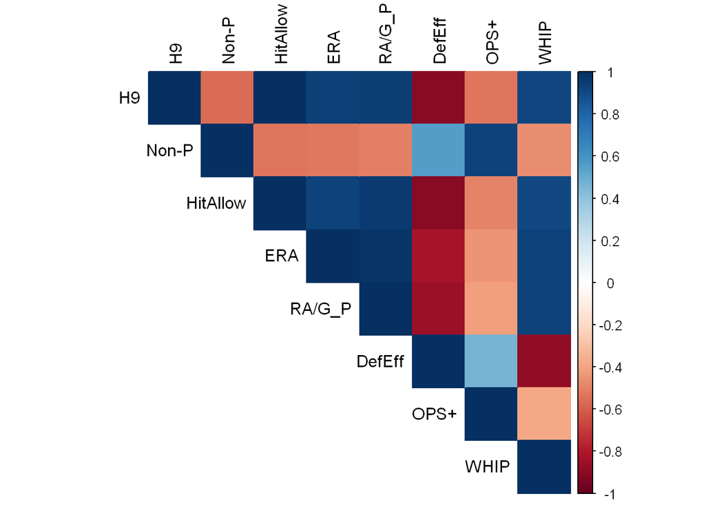

```r
vars <- c("H9","Non-P","HitAllow","ERA","RA/G_P","DefEff","OPS+","WHIP")

cor_matrix <- cor(train_data[, vars], use = "pairwise.complete.obs")


corrplot(cor_matrix, method = "color", type = "upper", tl.col = "black")
```

VIF > 10 : H9, Non-P, HitAllow, ERA, RA/G_P, OPS+, WHIP

VIF > 5 : DeffEff

The reason I believe there are so much high VIFs among the variables is because most of the variables are defensive stats. Some of the stats I might have overlooked and they might have had a hand in calculating another staff. H9 and Hitallow are definitely redundant, the model can definitely lose one of them, have to do further investigation to figure out which. Defensive efficieny is a measure of a teams fielding + pitching effectiveness and one of the stats used to calculate it is hitallow. The peculiar instance is OPS+ and Non-P with high VIFs but I believe those stats will go down when we elminated the redundant variables.

```r
set.seed(123)


model2 <- lm(
  as.formula("W ~ H9 + `Non-P` + ERA + `RA/G_P` + `OPS+` + WHIP"),
  data = test_data
)

summary(model2)
```

```
##
## Call:
## lm(formula = as.formula("W ~ H9 + `Non-P` + ERA + `RA/G_P` + `OPS+` + WHIP"),
##     data = test_data)
##
## Residuals:
##       1       2       3       4       5       6       7       8       9
## -0.3688 -0.7133 -0.5773  1.2485  1.3212 -0.6407  1.3802 -0.6341 -1.0156
##
## Coefficients:
##              Estimate Std. Error t value Pr(>|t|)
## (Intercept) -25.98731   41.37995  -0.628   0.5941
## H9           -2.13015    7.37964  -0.289   0.8000
## `Non-P`       0.02979    0.19942   0.149   0.8950
## ERA         -75.49605   30.04014  -2.513   0.1285
## `RA/G_P`     54.94544   28.76036   1.910   0.1963
## `OPS+`        1.46001    0.25647   5.693   0.0295 *
## WHIP         36.93165   66.55814   0.555   0.6348
## ---
## Signif. codes:  0 '***' 0.001 '**' 0.01 '*' 0.05 '.' 0.1 ' ' 1
##
## Residual standard error: 2.004 on 2 degrees of freedom
## Multiple R-squared:  0.9969, Adjusted R-squared:  0.9877
## F-statistic: 107.8 on 6 and 2 DF,  p-value: 0.009217
```

Eliminated HitAllow based of it had a higher p-value and less significant. Eliminated DefEff based on it has high multicollinearity with too many of the variables.

## 3. Step 3 - Residual Analysis

#model1

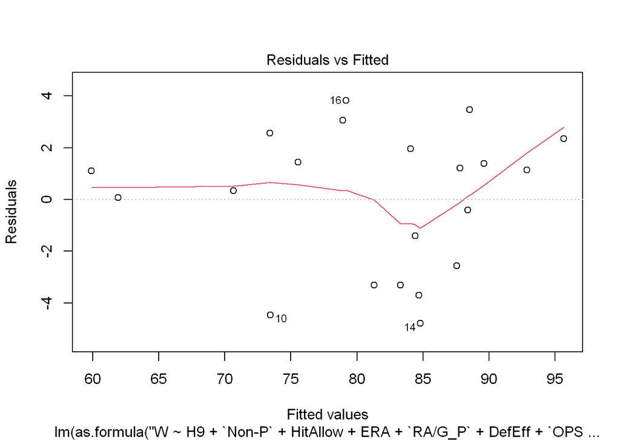

```r
plot(model1, which = 1)
```

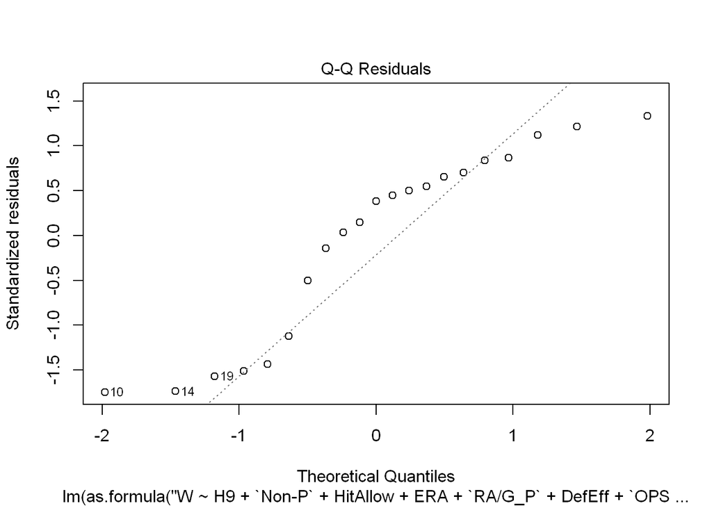

```r
plot(model1, which = 2)
```

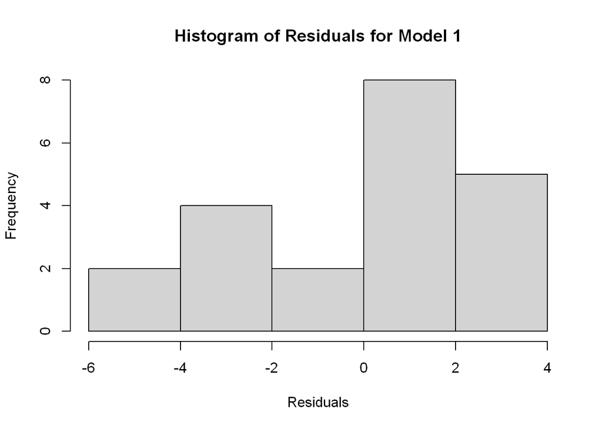

```r
hist(residuals(model1),
     main = "Histogram of Residuals for Model 1",
     xlab = "Residuals")
```

#model2

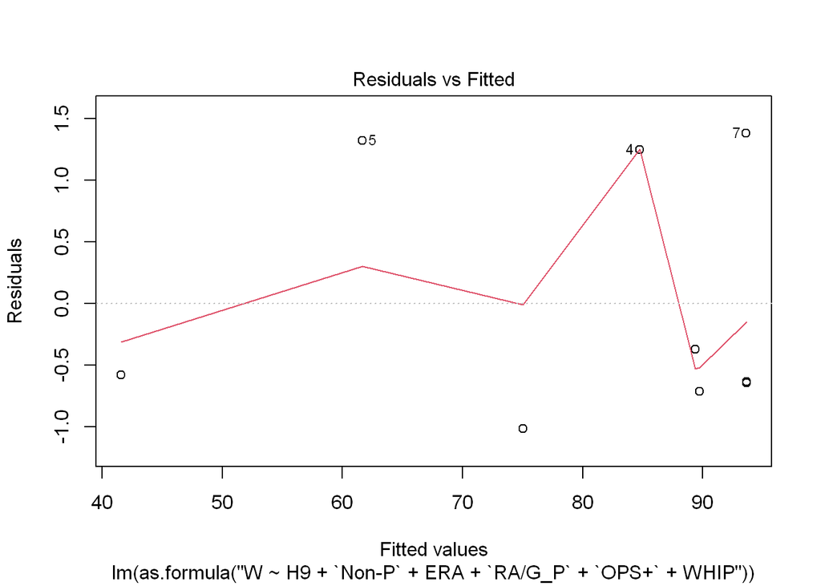

```r
plot(model2, which = 1)
```

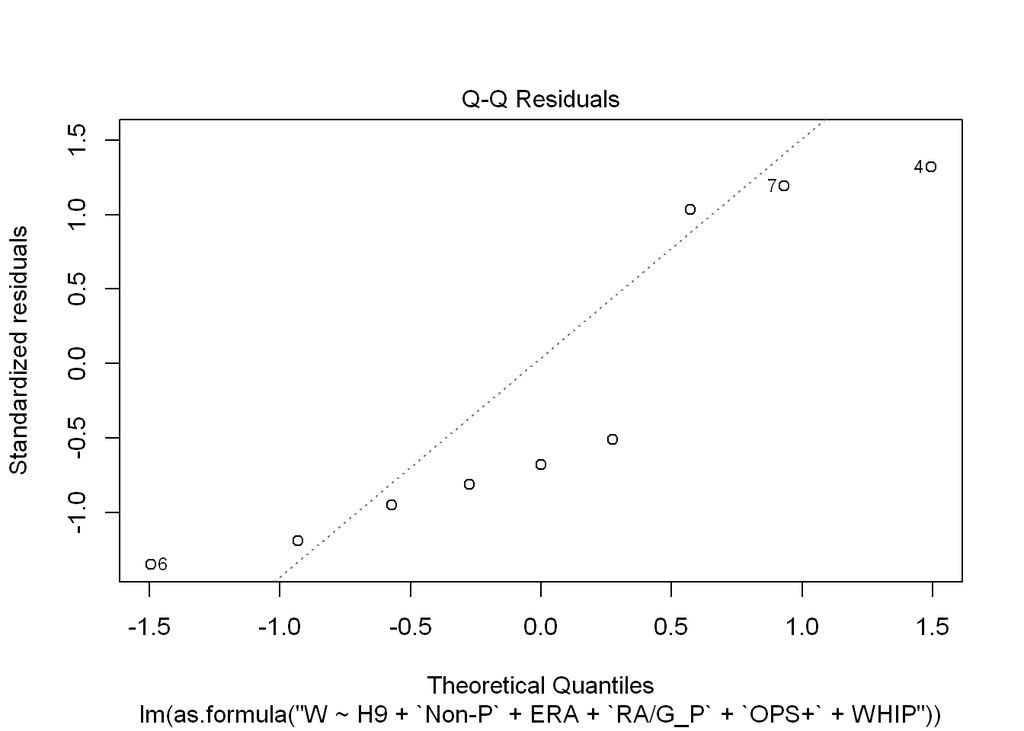

```r
plot(model2, which = 2)
```

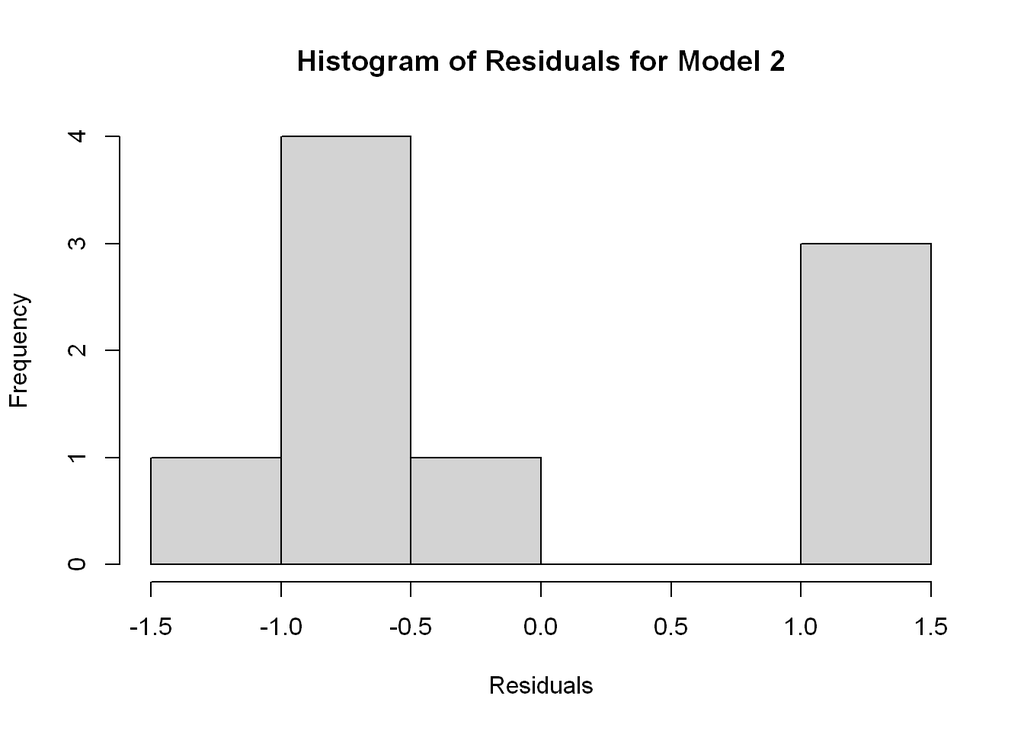

```r
hist(residuals(model2),
     main = "Histogram of Residuals for Model 2",
     xlab = "Residuals")
```

## 4. Step 4 – Model Assessment with Testing Data

```r
pred_test <- predict(model2, newdata = test_data)
RMSE <- sqrt(mean((test_data$W - pred_test)^2))
summary(pred_test)
```

```
##    Min. 1st Qu.  Median    Mean 3rd Qu.    Max.
##   41.58   75.02   89.37   80.33   93.62   93.64
```

```r
RMSE
```

```
## [1] 0.9446552
```

Although R^2 values are high for both model 1(~0.92) and model 2(~1), I don’t believe the model has good generalizaiation. The RMSE is very low and the R^2 and R^2 adjusted are very high for model 2 indicating over fitting. I believe it is because the data set is to small doing a train test split on a dataset of 30 datapoints. Might add 2023 and 2022 data as EDA of both show they have similar trends with 2024 data.